# report

1.data analysing: analysing the data. the process of analysing the large data set. 2. data set: collection of information or values which are particular to onr subject or group 3. data sci: processing large data

```python
import pandas as pd
df=pd.read_csv("crimeJ.csv")
df.head()#SAMPLE VALUES FROM TOP
```

|  | cdatetime | address | district | beat | grid | crimedescr | ucr_ncic_code | latitude | longitude |
| --- | --- | --- | --- | --- | --- | --- | --- | --- | --- |
| 0 | 1/1/06 0:00 | 3108 OCCIDENTAL DR | 3 | 3C | 1115 | 10851(A)VC TAKE VEH W/O OWNER | 2404 | 38.550420 | -121.391416 |
| 1 | 1/1/06 0:00 | 2082 EXPEDITION WAY | 5 | 5A | 1512 | 459 PC BURGLARY RESIDENCE | 2204 | 38.473501 | -121.490186 |
| 2 | 1/1/06 0:00 | 4 PALEN CT | 2 | 2A | 212 | 10851(A)VC TAKE VEH W/O OWNER | 2404 | 38.657846 | -121.462101 |
| 3 | 1/1/06 0:00 | 22 BECKFORD CT | 6 | 6C | 1443 | 476 PC PASS FICTICIOUS CHECK | 2501 | 38.506774 | -121.426951 |
| 4 | 1/1/06 0:00 | 3421 AUBURN BLVD | 2 | 2A | 508 | 459 PC BURGLARY-UNSPECIFIED | 2299 | 38.637448 | -121.384613 |

```python
df.tail()#SAMPLE VALUES FROM BOTTOM
```

|  | cdatetime | address | district | beat | grid | crimedescr | ucr_ncic_code | latitude | longitude |
| --- | --- | --- | --- | --- | --- | --- | --- | --- | --- |
| 7579 | 1/31/06 23:36 | 26TH ST / G ST | 3 | 3B | 728 | 594(B)(2)(A) VANDALISM/ -$400 | 2999 | 38.577832 | -121.470460 |
| 7580 | 1/31/06 23:40 | 4011 FREEPORT BLVD | 4 | 4A | 957 | 459 PC BURGLARY BUSINESS | 2203 | 38.537591 | -121.492591 |
| 7581 | 1/31/06 23:41 | 30TH ST / K ST | 3 | 3C | 841 | TRAFFIC-ACCIDENT INJURY | 5400 | 38.572030 | -121.467012 |
| 7582 | 1/31/06 23:45 | 5303 FRANKLIN BLVD | 4 | 4B | 969 | 3056 PAROLE VIO - I RPT | 7000 | 38.527187 | -121.471248 |
| 7583 | 1/31/06 23:50 | COBBLE COVE LN / COBBLE SHORES DR | 4 | 4C | 1294 | TRAFFIC-ACCIDENT-NON INJURY | 5400 | 38.479628 | -121.528634 |

```python
df.head(3)#TO GET PARTICULAR NO.OF TOP VALUES
```

|  | cdatetime | address | district | beat | grid | crimedescr | ucr_ncic_code | latitude | longitude |
| --- | --- | --- | --- | --- | --- | --- | --- | --- | --- |
| 0 | 1/1/06 0:00 | 3108 OCCIDENTAL DR | 3 | 3C | 1115 | 10851(A)VC TAKE VEH W/O OWNER | 2404 | 38.550420 | -121.391416 |
| 1 | 1/1/06 0:00 | 2082 EXPEDITION WAY | 5 | 5A | 1512 | 459 PC BURGLARY RESIDENCE | 2204 | 38.473501 | -121.490186 |
| 2 | 1/1/06 0:00 | 4 PALEN CT | 2 | 2A | 212 | 10851(A)VC TAKE VEH W/O OWNER | 2404 | 38.657846 | -121.462101 |

```python
df.tail(2) #TO GET PARTICULAR NO.OF LAST VALUES
```

|  | cdatetime | address | district | beat | grid | crimedescr | ucr_ncic_code | latitude | longitude |
| --- | --- | --- | --- | --- | --- | --- | --- | --- | --- |
| 7582 | 1/31/06 23:45 | 5303 FRANKLIN BLVD | 4 | 4B | 969 | 3056 PAROLE VIO - I RPT | 7000 | 38.527187 | -121.471248 |
| 7583 | 1/31/06 23:50 | COBBLE COVE LN / COBBLE SHORES DR | 4 | 4C | 1294 | TRAFFIC-ACCIDENT-NON INJURY | 5400 | 38.479628 | -121.528634 |

```python
df.sort_values("district") #SORT BY DISTRICT ORDER
```

|  | cdatetime | address | district | beat | grid | crimedescr | ucr_ncic_code | latitude | longitude |
| --- | --- | --- | --- | --- | --- | --- | --- | --- | --- |
| 4367 | 1/18/06 22:00 | 1671 W EL CAMINO AVE | 1 | 1B | 434 | 10851(A)VC TAKE VEH W/O OWNER | 2404 | 38.613539 | -121.499806 |
| 1425 | 1/7/06 0:30 | 4601 BLACKROCK DR | 1 | 1A | 136 | 459 PC BURGLARY VEHICLE | 2299 | 38.657333 | -121.495213 |
| 1420 | 1/7/06 0:01 | 5948 MEEKS WAY | 1 | 1A | 106 | 1708 US THEFT OF MAIL | 2310 | 38.683789 | -121.496349 |
| 1411 | 1/7/06 0:00 | 3260 NORDYKE DR | 1 | 1C | 418 | 459 PC BURGLARY VEHICLE | 2299 | 38.626506 | -121.476455 |
| 1409 | 1/7/06 0:00 | 3410 SHADOW TREE DR | 1 | 1B | 401 | 10851(A)VC TAKE VEH W/O OWNER | 2404 | 38.628525 | -121.505960 |
| ... | ... | ... | ... | ... | ... | ... | ... | ... | ... |
| 3108 | 1/13/06 18:00 | 3264 RAMONA AVE | 6 | 6C | 1113 | 10851(A)VC TAKE VEH W/O OWNER | 2404 | 38.545224 | -121.415719 |
| 3105 | 1/13/06 18:00 | 15 CARTHAGE CT | 6 | 6C | 1443 | MISSING PERSON | 7000 | 38.505769 | -121.418114 |
| 6430 | 1/27/06 9:45 | 8151 POWER RIDGE RD | 6 | 6C | 1145 | 10851 VC AUTO THEFT LOCATE | 2404 | 38.531579 | -121.407542 |
| 1553 | 1/7/06 16:10 | 3946 2ND AVE | 6 | 6A | 1014 | 459 PC BURGLARY RESIDENCE | 2204 | 38.550676 | -121.461860 |
| 3791 | 1/16/06 22:00 | 5961 13TH AVE | 6 | 6B | 1056 | 459 PC BURGLARY VEHICLE | 2299 | 38.540424 | -121.436176 |

7584 rows × 9 columns

```python
df["grid"].mean()#MEAN
```

```
916.2507911392405
```

```python
df["grid"].max()#MAX VALUE
```

```
1661
```

```python
df["grid"].min()#MIN VALUE
```

```
102
```

```python
df.describe()#DESCRIBE
```

|  | district | grid | ucr_ncic_code | latitude | longitude |
| --- | --- | --- | --- | --- | --- |
| count | 7584.000000 | 7584.000000 | 7584.000000 | 7584.000000 | 7584.000000 |
| mean | 3.574631 | 916.250791 | 4275.068829 | 38.559809 | -121.463832 |
| std | 1.642512 | 407.436310 | 2171.593193 | 0.056101 | 0.034621 |
| min | 1.000000 | 102.000000 | 909.000000 | 38.437999 | -121.555832 |
| 25% | 2.000000 | 567.000000 | 2309.000000 | 38.518476 | -121.489543 |
| 50% | 3.000000 | 899.000000 | 3532.000000 | 38.559523 | -121.465459 |
| 75% | 5.000000 | 1264.000000 | 7000.000000 | 38.610361 | -121.435947 |
| max | 6.000000 | 1661.000000 | 8102.000000 | 38.683789 | -121.365238 |

```python
df['beat'] #COLOUMN
```

```
0       3C
1       5A
2       2A
3       6C
4       2A
           ...
7579    3B
7580    4A
7581    3C
7582    4B
7583    4C
Name: beat, Length: 7584, dtype: object
```

```python
df[['district','address']]#COLOUMN SLICING
```

|  | district | address |
| --- | --- | --- |
| 0 | 3 | 3108 OCCIDENTAL DR |
| 1 | 5 | 2082 EXPEDITION WAY |
| 2 | 2 | 4 PALEN CT |
| 3 | 6 | 22 BECKFORD CT |
| 4 | 2 | 3421 AUBURN BLVD |
| ... | ... | ... |
| 7579 | 3 | 26TH ST / G ST |
| 7580 | 4 | 4011 FREEPORT BLVD |
| 7581 | 3 | 30TH ST / K ST |
| 7582 | 4 | 5303 FRANKLIN BLVD |
| 7583 | 4 | COBBLE COVE LN / COBBLE SHORES DR |

7584 rows × 2 columns

```python
#TO GET INFORMATION OF THE DATA TYPE
df=pd.read_csv('crimeJ.csv')
df.info()
df.head()
```

```
<class 'pandas.core.frame.DataFrame'>
RangeIndex: 7584 entries, 0 to 7583
Data columns (total 9 columns):
cdatetime        7584 non-null object
address          7584 non-null object
district         7584 non-null int64
beat             7584 non-null object
grid             7584 non-null int64
crimedescr       7584 non-null object
ucr_ncic_code    7584 non-null int64
latitude         7584 non-null float64
longitude        7584 non-null float64
dtypes: float64(2), int64(3), object(4)
memory usage: 533.4+ KB
```

|  | cdatetime | address | district | beat | grid | crimedescr | ucr_ncic_code | latitude | longitude |
| --- | --- | --- | --- | --- | --- | --- | --- | --- | --- |
| 0 | 1/1/06 0:00 | 3108 OCCIDENTAL DR | 3 | 3C | 1115 | 10851(A)VC TAKE VEH W/O OWNER | 2404 | 38.550420 | -121.391416 |
| 1 | 1/1/06 0:00 | 2082 EXPEDITION WAY | 5 | 5A | 1512 | 459 PC BURGLARY RESIDENCE | 2204 | 38.473501 | -121.490186 |
| 2 | 1/1/06 0:00 | 4 PALEN CT | 2 | 2A | 212 | 10851(A)VC TAKE VEH W/O OWNER | 2404 | 38.657846 | -121.462101 |
| 3 | 1/1/06 0:00 | 22 BECKFORD CT | 6 | 6C | 1443 | 476 PC PASS FICTICIOUS CHECK | 2501 | 38.506774 | -121.426951 |
| 4 | 1/1/06 0:00 | 3421 AUBURN BLVD | 2 | 2A | 508 | 459 PC BURGLARY-UNSPECIFIED | 2299 | 38.637448 | -121.384613 |

```python
#LISTS
import pandas as pd
name=['elena','bonnie','jake','ian','paul']
df=pd.DataFrame(name)
df
```

|  | 0 |
| --- | --- |
| 0 | elena |
| 1 | bonnie |
| 2 | jake |
| 3 | ian |
| 4 | paul |

```python
#column and row acccess using list
data=[['elena',30],['ian',40],['paul',37]]
pd.DataFrame(data,index=[1,2,3],columns=['name','age'])
```

|  | name | age |
| --- | --- | --- |
| 1 | elena | 30 |
| 2 | ian | 40 |
| 3 | paul | 37 |

```python
#DICTIONARIES
import pandas as pd
food={'name':['pizza','noodles','biriyani','ice cream'],'price':[225,200,270,110]}
df=pd.DataFrame(food,index=[1,2,3,4])
df
```

|  | name | price |
| --- | --- | --- |
| 1 | pizza | 225 |
| 2 | noodles | 200 |
| 3 | biriyani | 270 |
| 4 | ice cream | 110 |

```python
#TO DELETE A ROW
df.drop(3)
```

|  | name | price |
| --- | --- | --- |
| 1 | pizza | 225 |
| 2 | noodles | 200 |
| 4 | ice cream | 110 |

```python
#TO DELETE A COLUMN
del df['price']
df
```

|  | name |
| --- | --- |
| 1 | pizza |
| 2 | noodles |
| 3 | biriyani |
| 4 | ice cream |

```python
 #cleaning data
import pandas as pd
exam={'s1':[15,13,20],'s2':[12,17,10],'s3':[13,15,19]}# CREATING NESTED DICTIONARY
df=pd.DataFrame(exam,index=['elena','damon','stefan'])# GIVING NAME TO THR ROWS
df
```

|  | s1 | s2 | s3 |
| --- | --- | --- | --- |
| elena | 15 | 12 | 13 |
| damon | 13 | 17 | 15 |
| stefan | 20 | 10 | 19 |

```python
#reindex() function conform DataFrame to new index with optional filling logic
df=df.reindex(['elena','damon','stefan','jermy'])
df
```

|  | s1 | s2 | s3 |
| --- | --- | --- | --- |
| elena | 15.0 | 12.0 | 13.0 |
| damon | 13.0 | 17.0 | 15.0 |
| stefan | 20.0 | 10.0 | 19.0 |
| jermy | NaN | NaN | NaN |

```python
 #fillna allows the user replace NaN values with some value of their own
df.fillna('absent')
```

|  | s1 | s2 | s3 |
| --- | --- | --- | --- |
| elena | 15 | 12 | 13 |
| damon | 13 | 17 | 15 |
| stefan | 20 | 10 | 19 |
| jermy | absent | absent | absent |

```python
#dropna used to manage and remove Null values from a data frame
df.dropna()
```

|  | s1 | s2 | s3 |
| --- | --- | --- | --- |
| elena | 15.0 | 12.0 | 13.0 |
| damon | 13.0 | 17.0 | 15.0 |
| stefan | 20.0 | 10.0 | 19.0 |

```python
# to replace a value
df.replace({19:100,15:200})
```

|  | s1 | s2 | s3 |
| --- | --- | --- | --- |
| elena | 200.0 | 12.0 | 13.0 |
| damon | 13.0 | 17.0 | 200.0 |
| stefan | 20.0 | 10.0 | 100.0 |
| jermy | NaN | NaN | NaN |

```python
# groupby:
import pandas as pd
df = pd.read_csv("ndata.csv")
df
```

|  | name | age | salary |
| --- | --- | --- | --- |
| 0 | elena | 17 | 12000 |
| 1 | damon | 19 | 15000 |
| 2 | elena | 17 | 30000 |
| 3 | damon | 19 | 45000 |
| 4 | stafan | 20 | 50000 |

```python
name=df.groupby('name')
```

```python
name
```

```
<pandas.core.groupby.generic.DataFrameGroupBy object at 0x00000149D1186CC8>
```

```python
name.mean()# grouping by name
```

| name | age | salary |
| --- | --- | --- |
| damon | 19 | 30000 |
| elena | 17 | 21000 |
| stafan | 20 | 50000 |

```python
name.max()# groupby max
```

| name | age | salary |
| --- | --- | --- |
| damon | 19 | 45000 |
| elena | 17 | 30000 |
| stafan | 20 | 50000 |

```python
name.min()# groupby min
```

| name | age | salary |
| --- | --- | --- |
| damon | 19 | 15000 |
| elena | 17 | 12000 |
| stafan | 20 | 50000 |

```python
name.sum()
```

| name | age | salary |
| --- | --- | --- |
| damon | 38 | 60000 |
| elena | 34 | 42000 |
| stafan | 20 | 50000 |

```python
name.std
```

```
<bound method GroupBy.std of <pandas.core.groupby.generic.DataFrameGroupBy object at 0x00000149D1186CC8>>
```

```python
name.count()
```

| name | age | salary |
| --- | --- | --- |
| damon | 2 | 2 |
| elena | 2 | 2 |
| stafan | 1 | 1 |

```python
name.describe()
```

| name | age count | age mean | age std | age min | age 25% | age 50% | age 75% | age max | salary count | salary mean | salary std | salary min | salary 25% | salary 50% | salary 75% | salary max |
| --- | --- | --- | --- | --- | --- | --- | --- | --- | --- | --- | --- | --- | --- | --- | --- | --- |
| damon | 2.0 | 19.0 | 0.0 | 19.0 | 19.0 | 19.0 | 19.0 | 19.0 | 2.0 | 30000.0 | 21213.203436 | 15000.0 | 22500.0 | 30000.0 | 37500.0 | 45000.0 |
| elena | 2.0 | 17.0 | 0.0 | 17.0 | 17.0 | 17.0 | 17.0 | 17.0 | 2.0 | 21000.0 | 12727.922061 | 12000.0 | 16500.0 | 21000.0 | 25500.0 | 30000.0 |
| stafan | 1.0 | 20.0 | NaN | 20.0 | 20.0 | 20.0 | 20.0 | 20.0 | 1.0 | 50000.0 | NaN | 50000.0 | 50000.0 | 50000.0 | 50000.0 | 50000.0 |

```python
name.describe().transpose()
```

|  | name | damon | elena | stafan |
| --- | --- | --- | --- | --- |
| age | count | 2.000000 | 2.000000 | 1.0 |
|  | mean | 19.000000 | 17.000000 | 20.0 |
|  | std | 0.000000 | 0.000000 | NaN |
|  | min | 19.000000 | 17.000000 | 20.0 |
|  | 25% | 19.000000 | 17.000000 | 20.0 |
|  | 50% | 19.000000 | 17.000000 | 20.0 |
|  | 75% | 19.000000 | 17.000000 | 20.0 |
|  | max | 19.000000 | 17.000000 | 20.0 |
| salary | count | 2.000000 | 2.000000 | 1.0 |
|  | mean | 30000.000000 | 21000.000000 | 50000.0 |
|  | std | 21213.203436 | 12727.922061 | NaN |
|  | min | 15000.000000 | 12000.000000 | 50000.0 |
|  | 25% | 22500.000000 | 16500.000000 | 50000.0 |
|  | 50% | 30000.000000 | 21000.000000 | 50000.0 |
|  | 75% | 37500.000000 | 25500.000000 | 50000.0 |
|  | max | 45000.000000 | 30000.000000 | 50000.0 |

```python
#THREE SHEETS IN ONE EXCEL FILE:
import pandas as pd
d1={'v':['stefan','ian','paul','damon'],
     'm1':[4,2,3,5]}
d2={'h':['jermy','elena','nina','matt'],
    'm2':[3,5,3,4]}
d3={'w':['bonnie','cal','ben','mick'],
    'm3':[1,3,5,2]}
data1=pd.DataFrame(d1)
data2=pd.DataFrame(d2)
data3=pd.DataFrame(d3)
with pd.ExcelWriter('assignment.xlsx') as w:
    data1.to_excel(w,sheet_name='sheet1')
    data2.to_excel(w,sheet_name='sheet2')
    data3.to_excel(w,sheet_name='sheet3')
```

```python
data1
```

|  | v | m1 |
| --- | --- | --- |
| 0 | stefan | 4 |
| 1 | ian | 2 |
| 2 | paul | 3 |
| 3 | damon | 5 |

```python
data2
```

|  | h | m2 |
| --- | --- | --- |
| 0 | jermy | 3 |
| 1 | elena | 5 |
| 2 | nina | 3 |
| 3 | matt | 4 |

```python
data3
```

|  | w | m3 |
| --- | --- | --- |
| 0 | bonnie | 1 |
| 1 | cal | 3 |
| 2 | ben | 5 |
| 3 | mick | 2 |

```python
data1.info()
```

```
<class 'pandas.core.frame.DataFrame'>
RangeIndex: 4 entries, 0 to 3
Data columns (total 2 columns):
v     4 non-null object
m1    4 non-null int64
dtypes: int64(1), object(1)
memory usage: 192.0+ bytes
```

```python
data2.info()
```

```
<class 'pandas.core.frame.DataFrame'>
RangeIndex: 4 entries, 0 to 3
Data columns (total 2 columns):
h     4 non-null object
m2    4 non-null int64
dtypes: int64(1), object(1)
memory usage: 192.0+ bytes
```

```python
data3.info()
```

```
<class 'pandas.core.frame.DataFrame'>
RangeIndex: 4 entries, 0 to 3
Data columns (total 2 columns):
w     4 non-null object
m3    4 non-null int64
dtypes: int64(1), object(1)
memory usage: 192.0+ bytes
```

```python
data1.describe()
```

|  | m1 |
| --- | --- |
| count | 4.000000 |
| mean | 3.500000 |
| std | 1.290994 |
| min | 2.000000 |
| 25% | 2.750000 |
| 50% | 3.500000 |
| 75% | 4.250000 |
| max | 5.000000 |

```python
data2.describe()
```

|  | m2 |
| --- | --- |
| count | 4.000000 |
| mean | 3.750000 |
| std | 0.957427 |
| min | 3.000000 |
| 25% | 3.000000 |
| 50% | 3.500000 |
| 75% | 4.250000 |
| max | 5.000000 |

```python
data3.describe()
```

|  | m3 |
| --- | --- |
| count | 4.000000 |
| mean | 2.750000 |
| std | 1.707825 |
| min | 1.000000 |
| 25% | 1.750000 |
| 50% | 2.500000 |
| 75% | 3.500000 |
| max | 5.000000 |

```python
# data scaling:
## Load digit
from sklearn.datasets import load_digits
from sklearn import preprocessing
digits = load_digits()
print(digits.data.shape)
```

```
(1797, 64)
```

```python
x1=digits.data
y1=digits.target
n1=preprocessing.normalize(x1)
print(n1)
```

```
[[0.         0.         0.09024036 ... 0.         0.         0.        ]
 [0.         0.         0.         ... 0.15413829 0.         0.        ]
 [0.         0.         0.         ... 0.24153867 0.1358655  0.        ]
 ...
 [0.         0.         0.0140138  ... 0.08408278 0.         0.        ]
 [0.         0.         0.03044313 ... 0.18265877 0.         0.        ]
 [0.         0.         0.14230641 ... 0.17076769 0.01423064 0.        ]]
```

```python
preprocessing.scale(x1)
```

```
array([[ 0.        , -0.33501649, -0.04308102, ..., -1.14664746,
        -0.5056698 , -0.19600752],
       [ 0.        , -0.33501649, -1.09493684, ...,  0.54856067,
        -0.5056698 , -0.19600752],
       [ 0.        , -0.33501649, -1.09493684, ...,  1.56568555,
         1.6951369 , -0.19600752],
       ...,
       [ 0.        , -0.33501649, -0.88456568, ..., -0.12952258,
        -0.5056698 , -0.19600752],
       [ 0.        , -0.33501649, -0.67419451, ...,  0.8876023 ,
        -0.5056698 , -0.19600752],
       [ 0.        , -0.33501649,  1.00877481, ...,  0.8876023 ,
        -0.26113572, -0.19600752]])
```

# NUMPY

```python
import numpy as np #importing the numpy pakeage
```

```python
arr=[1,2,3,5,6,9] #creating a list of numbers
np.array(arr) #THIS IS TO PRINT THE LIST AS A 1D ARRAY
```

```
array([1, 2, 3, 5, 6, 9])
```

```python
mat=[[1,3,5],[2,4,6],[7,8,9]]# CREATING USING A NESTED LIST
np.array(mat)# THIS IS TO PRINT THE LIST AS A 2D ARRAY
```

```
array([[1, 3, 5],
       [2, 4, 6],
       [7, 8, 9]])
```

```python
a=np.arange(0,20,2) #np.arange(start,stop,step)to return evenly spaced values within a given intervals
```

```python
a
```

```
array([ 0,  2,  4,  6,  8, 10, 12, 14, 16, 18])
```

```python
# IT RETURNS A ARRAY OF GIVEN SHAPE AND TYPE WITH ZEROS
np.zeros(5)#1D ARRAY
```

```
array([0., 0., 0., 0., 0.])
```

```python
np.zeros((2,2))#2D ARRAY
```

```
array([[0., 0.],
       [0., 0.]])
```

```python
# IT RETURNS A ARRAY OF GIVEN SHAPE AND TYPE WITH ONES
np.ones(3)#1D ARRAY
```

```
array([1., 1., 1.])
```

```python
np.ones((3,3))# 2D ARRAY
```

```
array([[1., 1., 1.],
       [1., 1., 1.],
       [1., 1., 1.]])
```

```python
#Return a matrix having 1's on the diagonal and 0's elsewhere(identity matrix)
np.eye(4,4)
```

```
array([[1., 0., 0., 0.],
       [0., 1., 0., 0.],
       [0., 0., 1., 0.],
       [0., 0., 0., 1.]])
```

```python
#numpy. linspace (start, stop, num=50)
#creating numeric sequences,similar to arange function.
#it prints the linearly spaced vectors
np.linspace(0,5,10)
```

```
array([0.        , 0.55555556, 1.11111111, 1.66666667, 2.22222222,
       2.77777778, 3.33333333, 3.88888889, 4.44444444, 5.        ])
```

```python
# creates an array of specified shape and fills it with positive random values.
np.random.rand(5)
```

```
array([0.43237861, 0.55843269, 0.49656912, 0.56702275, 0.71339312])
```

```python
#creates an array of specified shape and fills it with random values both positive and negative.
np.random.randn(4)
```

```
array([-1.03105556, -2.06307735, -0.49439508,  0.07424895])
```

```python
#It returns an array of specified shape and fills it with random integers from low to high
np.random.randint(1,10,5)
```

```
array([7, 4, 8, 1, 9])
```

```python
#reshape function is used to give a new shape to an array without changing its data.J
a.reshape(5,2)
```

```
array([[ 0,  2],
       [ 4,  6],
       [ 8, 10],
       [12, 14],
       [16, 18]])
```

```python
a.max()# prints the maximum value
```

```
18
```

```python
a.argmax()# prints the index of the maximum value
```

```
9
```

```python
a.min()# print the minimum value
```

```
0
```

```python
a.argmin()#print the index of the minimum value
```

```
0
```

```python
a.shape#returns the shape of the array
```

```
(10,)
```

```python
a.dtype
```

```
dtype('int32')
```

```python
# numpy indexing and selection
import numpy as np
```

```python
arr=np.arange(10)
```

```python
arr
```

```
array([0, 1, 2, 3, 4, 5, 6, 7, 8, 9])
```

```python
arr[2:7] #indexing the list from 2-6 leaving 7
```

```
array([2, 3, 4, 5, 6])
```

```python
arr>2 #to get a boolean value (i.e) numbers greater than 2 is TRUE, while others are FALSE
```

```
array([False, False, False,  True,  True,  True,  True,  True,  True,
        True])
```

```python
arr[arr>2] #TO print all the numbers greater than two
```

```
array([3, 4, 5, 6, 7, 8, 9])
```

```python
# 2d array
import  numpy as np
```

```python
mat=np.array([[1,2,3],[4,5,6],[7,8,9]])
```

```python
mat
```

```
array([[1, 2, 3],
       [4, 5, 6],
       [7, 8, 9]])
```

```python
mat[0] #TO PRINT THE FIRST ROW
```

```
array([1, 2, 3])
```

```python
mat[1,2] #TO PRINT THE ELEMENT IN THE 1ST ROW,2ND COL
```

```
6
```

```python
mat[:2,2:]
```

```
array([[3],
       [6]])
```

```python
mat[1:,1:]
```

```
array([[5, 6],
       [8, 9]])
```

```python
# numpy arithmetic operations
import numpy as np
```

```python
arr=np.arange(0,20)
```

```python
arr
```

```
array([ 0,  1,  2,  3,  4,  5,  6,  7,  8,  9, 10, 11, 12, 13, 14, 15, 16,
       17, 18, 19])
```

```python
arr+arr#diff of the arr
```

```
array([ 0,  2,  4,  6,  8, 10, 12, 14, 16, 18, 20, 22, 24, 26, 28, 30, 32,
       34, 36, 38])
```

```python
arr-arr #diff of the arr
```

```
array([0, 0, 0, 0, 0, 0, 0, 0, 0, 0, 0, 0, 0, 0, 0, 0, 0, 0, 0, 0])
```

```python
arr*arr #pdt of the arr
```

```
array([  0,   1,   4,   9,  16,  25,  36,  49,  64,  81, 100, 121, 144,
       169, 196, 225, 256, 289, 324, 361])
```

```python
arr+100 # adding 100 to arr
```

```
array([100, 101, 102, 103, 104, 105, 106, 107, 108, 109, 110, 111, 112,
       113, 114, 115, 116, 117, 118, 119])
```

```python
arr-100 #subrating 100 from arr
```

```
array([-100,  -99,  -98,  -97,  -96,  -95,  -94,  -93,  -92,  -91,  -90,
        -89,  -88,  -87,  -86,  -85,  -84,  -83,  -82,  -81])
```

```python
arr*2 # multiplying 100 to arr
```

```
array([ 0,  2,  4,  6,  8, 10, 12, 14, 16, 18, 20, 22, 24, 26, 28, 30, 32,
       34, 36, 38])
```

```python
arr**2 #squaring the arr
```

```
array([  0,   1,   4,   9,  16,  25,  36,  49,  64,  81, 100, 121, 144,
       169, 196, 225, 256, 289, 324, 361], dtype=int32)
```

```python
np.sqrt(arr) #sqr root of arr
```

```
array([0.        , 1.        , 1.41421356, 1.73205081, 2.        ,
       2.23606798, 2.44948974, 2.64575131, 2.82842712, 3.        ,
       3.16227766, 3.31662479, 3.46410162, 3.60555128, 3.74165739,
       3.87298335, 4.        , 4.12310563, 4.24264069, 4.35889894])
```

```python
np.exp(arr) #exponential of arr
```

```
array([1.00000000e+00, 2.71828183e+00, 7.38905610e+00, 2.00855369e+01,
       5.45981500e+01, 1.48413159e+02, 4.03428793e+02, 1.09663316e+03,
       2.98095799e+03, 8.10308393e+03, 2.20264658e+04, 5.98741417e+04,
       1.62754791e+05, 4.42413392e+05, 1.20260428e+06, 3.26901737e+06,
       8.88611052e+06, 2.41549528e+07, 6.56599691e+07, 1.78482301e+08])
```

```python
np.max(arr) # max value of arr
```

```
19
```

```python
np.min(arr) #min value of arr
```

```
0
```

```python
np.sin(arr) # sine values of arr
```

```
array([ 0.        ,  0.84147098,  0.90929743,  0.14112001, -0.7568025 ,
       -0.95892427, -0.2794155 ,  0.6569866 ,  0.98935825,  0.41211849,
       -0.54402111, -0.99999021, -0.53657292,  0.42016704,  0.99060736,
        0.65028784, -0.28790332, -0.96139749, -0.75098725,  0.14987721])
```

```python
np.cos(arr)# cosine values of arr
```

```
array([ 1.        ,  0.54030231, -0.41614684, -0.9899925 , -0.65364362,
        0.28366219,  0.96017029,  0.75390225, -0.14550003, -0.91113026,
       -0.83907153,  0.0044257 ,  0.84385396,  0.90744678,  0.13673722,
       -0.75968791, -0.95765948, -0.27516334,  0.66031671,  0.98870462])
```

```python
np.tan(arr)# tan values of arr
```

```
array([ 0.00000000e+00,  1.55740772e+00, -2.18503986e+00, -1.42546543e-01,
        1.15782128e+00, -3.38051501e+00, -2.91006191e-01,  8.71447983e-01,
       -6.79971146e+00, -4.52315659e-01,  6.48360827e-01, -2.25950846e+02,
       -6.35859929e-01,  4.63021133e-01,  7.24460662e+00, -8.55993401e-01,
        3.00632242e-01,  3.49391565e+00, -1.13731371e+00,  1.51589471e-01])
```

```python
np.log(arr)# log values of arr
```

```
C:\Users\Anbu Nambi\Anaconda3\lib\site-packages\ipykernel_launcher.py:1: RuntimeWarning: divide by zero encountered in log
  """Entry point for launching an IPython kernel.
```

```
array([      -inf, 0.        , 0.69314718, 1.09861229, 1.38629436,
       1.60943791, 1.79175947, 1.94591015, 2.07944154, 2.19722458,
       2.30258509, 2.39789527, 2.48490665, 2.56494936, 2.63905733,
       2.7080502 , 2.77258872, 2.83321334, 2.89037176, 2.94443898])
```

# MATPLOTLIB

```python
# functional method:
```

```python
import matplotlib.pyplot as plt #importing the matplotlib package
```

```python
%matplotlib inline
# this is to see the plots created inside the jupyter notebook
```

```python
import numpy as np #importin the numpy package
```

```python
x=np.arange(0,10) #to spaced the values evenly within a given intervals of the x axis
y=x**2 #the square of the x values
```

```python
x
```

```
array([0, 1, 2, 3, 4, 5, 6, 7, 8, 9])
```

```python
y
```

```
array([ 0,  1,  4,  9, 16, 25, 36, 49, 64, 81], dtype=int32)
```

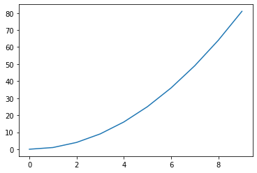

```python
plt.plot(x,y)# it is used to shows the plot
plt.show()# it is used to print the plot
```

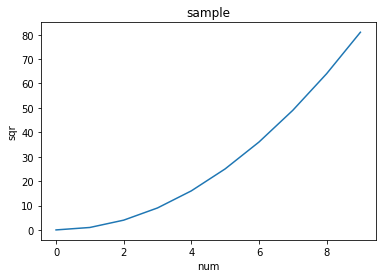

```python
plt.plot(x,y)
plt.xlabel('num')#labeling the xaxis
plt.ylabel('sqr')#labeling the yaxis
plt.title('sample')# naming the graph
```

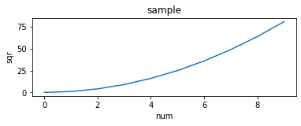

```python
plt.subplot(2,1,1) #plt.subplot(no.of row,no.of col,ref of plot no.)
plt.plot(x,y)
plt.xlabel('num')
plt.ylabel('sqr')
plt.title('sample')
```

```python
#object oreinted method:
```

```python
import matplotlib.pyplot as plt
%matplotlib inline
import numpy as np
```

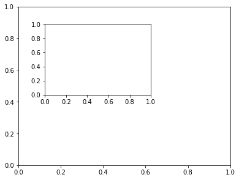

```python
fig=plt.figure()
axes1=fig.add_axes([.1,.2,.8,.9])
axes2=fig.add_axes([.2,.6,.4,.4])
```

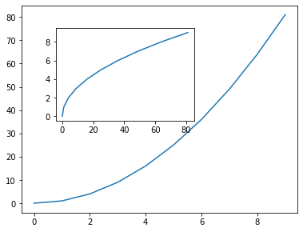

```python
fig=plt.figure()
axes1=fig.add_axes([.1,.2,.8,.9])
axes2=fig.add_axes([.2,.6,.4,.4])
axes1.plot(x,y)
axes2.plot(y,x)
```

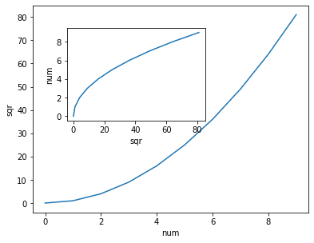

```python
fig=plt.figure()
axes1=fig.add_axes([.1,.2,.8,.9])
axes2=fig.add_axes([.2,.6,.4,.4])
axes1.plot(x,y)
axes2.plot(y,x)
axes1.set_xlabel('num')#big graph x axis
axes1.set_ylabel('sqr')#big graph y axis
axes2.set_ylabel('num')#small graph y axis
axes2.set_xlabel('sqr')#small graph x axis
```

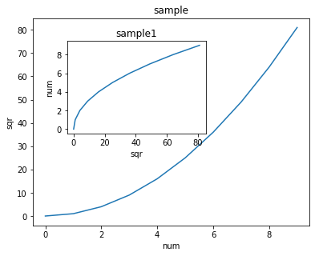

```python
fig=plt.figure()
axes1=fig.add_axes([.1,.2,.8,.9])
axes2=fig.add_axes([.2,.6,.4,.4])
axes1.plot(x,y)
axes2.plot(y,x)
axes1.set_xlabel('num')
axes1.set_ylabel('sqr')
axes2.set_ylabel('num')
axes2.set_xlabel('sqr')
axes1.set_title('sample') # naming the big graph
axes2.set_title('sample1') #naming the small graph
```

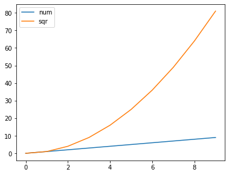

```python
fig=plt.figure()
axes1=fig.add_axes([.1,.2,.8,.9])
axes1.plot(x,label='num')
axes1.plot(y,label='sqr')
plt.legend(loc='best')
# choosing the best location to print the key/legend of the respective graph
```

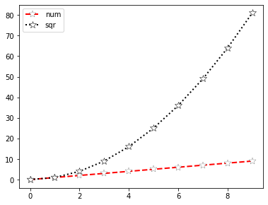

```python
fig=plt.figure()
axes1=fig.add_axes([.1,.2,.8,.9])
axes1.plot(x,label='num',color='red',lw=2,ls='--',marker='*',markersize='10',markerfacecolor='w',markeredgecolor='k',markeredgewidth='.2',)
axes1.plot(y,label='sqr',color='black',lw=2,ls=':',marker='*',markersize='10',markerfacecolor='w',markeredgecolor='k',markeredgewidth='.5',)
plt.legend(loc='best')
```

THE GRAPH CAN BE MADE MORE ATTRACTIVE AND EASILY UNDERSTOOD UDING THESE FUNCTIONS: *FROM THE ABOVE GRAPH I COMPARE THE NUMBERS AND THE SQUARE OF THE NUMBERS*LABEL: IT IS TO LABEL THE LINE I THE GRAPH *COLOUR: TO CHOOSE THE COLOR OF THE LINE*LINE WIDTH: TO SELECT THE WIDTH OF THE LINE *LINE STYLE: TO SELECT THE STYLE OF THE LINE*MARKER: TO SELECT THE SHAPE OF THE MARKER *MARKER SIZE: TO SELECT THE SIZE OF THE MARKER*MARKER FACE COLOR:TO CHOOSE THE COLOUR OF THE MARKER *MARKER EDGE COLOR:TO CHOOSE THE OUTLINE COLOR OF THE MARKER*MARKER EDGE WIDTH:TO CHOOSE THE WIDTH OF THE MARKER OUTLINE

- USING ALL THE FUNCTION THE GARPH CAN BE MADE MORE PRESENTABLE AND UNDERSTANGING.

# seaborn

```python
#distribution plots
```

```python
import seaborn as sns
%matplotlib inline
a=sns.load_dataset('car_crashes')
a.head()
```

|  | total | speeding | alcohol | not_distracted | no_previous | ins_premium | ins_losses | abbrev |
| --- | --- | --- | --- | --- | --- | --- | --- | --- |
| 0 | 18.8 | 7.332 | 5.640 | 18.048 | 15.040 | 784.55 | 145.08 | AL |
| 1 | 18.1 | 7.421 | 4.525 | 16.290 | 17.014 | 1053.48 | 133.93 | AK |
| 2 | 18.6 | 6.510 | 5.208 | 15.624 | 17.856 | 899.47 | 110.35 | AZ |
| 3 | 22.4 | 4.032 | 5.824 | 21.056 | 21.280 | 827.34 | 142.39 | AR |
| 4 | 12.0 | 4.200 | 3.360 | 10.920 | 10.680 | 878.41 | 165.63 | CA |

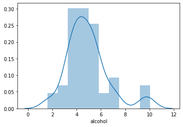

```python
sns.distplot(a['alcohol'])
```

The most convenient way to take a quick look at a univariate distribution in seaborn is the distplot() function. By default, this will draw a histogram and fit a kde. if kde= false the it will not be printed, *bins is used to adjust the size of the bar according to the graph

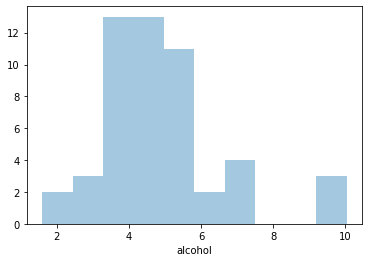

```python
sns.distplot(a['alcohol'], kde=False)
```

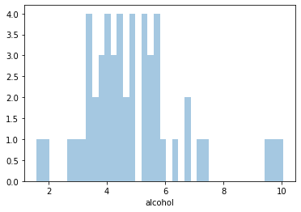

```python
sns.distplot(a['alcohol'], kde=False,bins=40)
```

the jointplot function creates a multi-figure that shows both the joint relationship between two variables along with the marginal) distribution of each axes

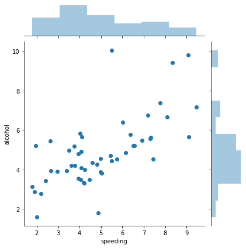

```python
sns.jointplot(x='speeding',y='alcohol',data=a)
```

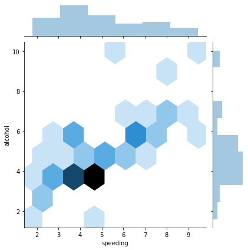

```python
sns.jointplot(x='speeding',y='alcohol',data=a,kind='hex')
```

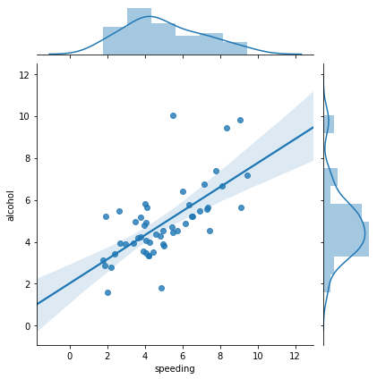

```python
sns.jointplot(x='speeding',y='alcohol',data=a,kind='reg')
```

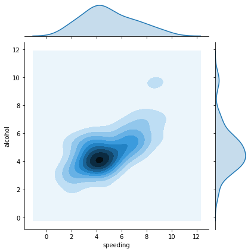

```python
sns.jointplot(x='speeding',y='alcohol',data=a,kind='kde')
```

the pairplot function creates a matrix of axes and shows the relationship for each pair of columns in a DataFrame.

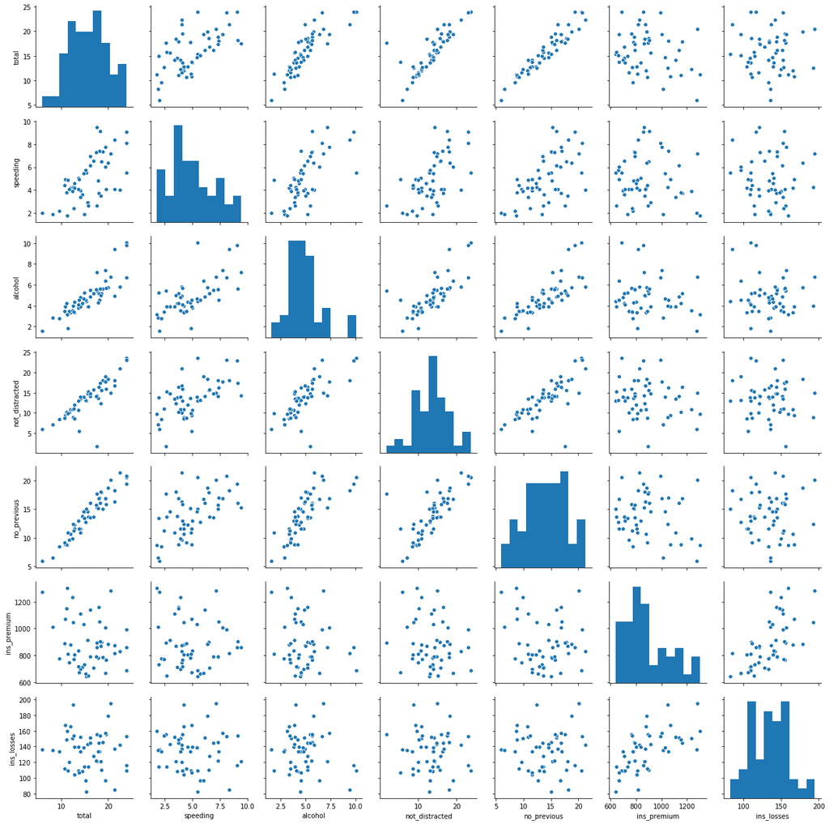

```python
sns.pairplot(a)
```

```python
# rug plot
```

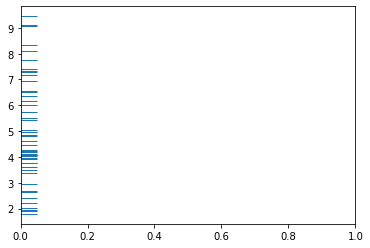

```python
sns.rugplot(a['speeding'],axis='y')
```

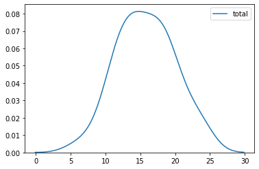

```python
sns.kdeplot(a['total'])
```

```python
#categorical plot:
```

```python
import seaborn as sns
%matplotlib inline
a=sns.load_dataset("dots")
a.head()
```

|  | align | choice | time | coherence | firing_rate |
| --- | --- | --- | --- | --- | --- |
| 0 | dots | T1 | -80 | 0.0 | 33.189967 |
| 1 | dots | T1 | -80 | 3.2 | 31.691726 |
| 2 | dots | T1 | -80 | 6.4 | 34.279840 |
| 3 | dots | T1 | -80 | 12.8 | 32.631874 |
| 4 | dots | T1 | -80 | 25.6 | 35.060487 |

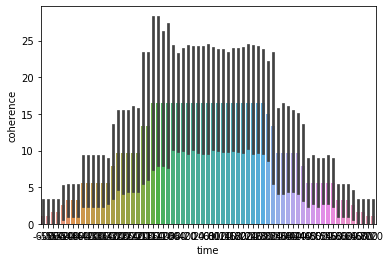

```python
import numpy as np
sns.barplot(x='time',y='coherence',data=a)#the graph seems to be gradually inceasing and decreasing
```

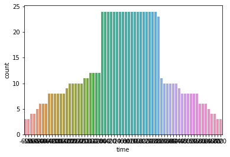

```python
sns.countplot(x='time',data=a)#here the time increases gradually in the middle and fall down back
```

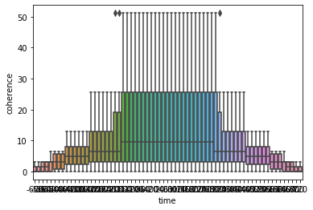

```python
sns.boxplot(x='time',y='coherence',data=a)
```

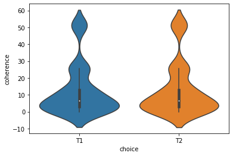

```python
sns.violinplot(x='choice',y='coherence',data=a)
```

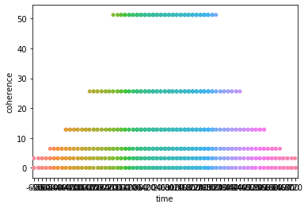

```python
sns.stripplot(x='time',y='coherence',data=a,jitter=True)
```

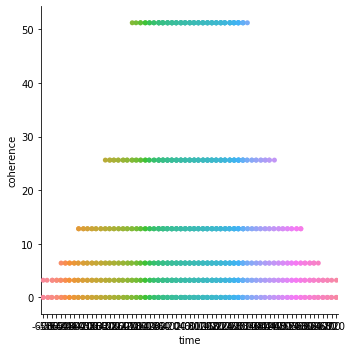

```python
sns.catplot(x='time',y='coherence',data=a)
```

# matrix plots

```python
import seaborn as sns
%matplotlib inline
a=sns.load_dataset('car_crashes')
b=sns.load_dataset('dots')
```

```python
a
```

|  | total | speeding | alcohol | not_distracted | no_previous | ins_premium | ins_losses | abbrev |
| --- | --- | --- | --- | --- | --- | --- | --- | --- |
| 0 | 18.8 | 7.332 | 5.640 | 18.048 | 15.040 | 784.55 | 145.08 | AL |
| 1 | 18.1 | 7.421 | 4.525 | 16.290 | 17.014 | 1053.48 | 133.93 | AK |
| 2 | 18.6 | 6.510 | 5.208 | 15.624 | 17.856 | 899.47 | 110.35 | AZ |
| 3 | 22.4 | 4.032 | 5.824 | 21.056 | 21.280 | 827.34 | 142.39 | AR |
| 4 | 12.0 | 4.200 | 3.360 | 10.920 | 10.680 | 878.41 | 165.63 | CA |
| 5 | 13.6 | 5.032 | 3.808 | 10.744 | 12.920 | 835.50 | 139.91 | CO |
| 6 | 10.8 | 4.968 | 3.888 | 9.396 | 8.856 | 1068.73 | 167.02 | CT |
| 7 | 16.2 | 6.156 | 4.860 | 14.094 | 16.038 | 1137.87 | 151.48 | DE |
| 8 | 5.9 | 2.006 | 1.593 | 5.900 | 5.900 | 1273.89 | 136.05 | DC |
| 9 | 17.9 | 3.759 | 5.191 | 16.468 | 16.826 | 1160.13 | 144.18 | FL |
| 10 | 15.6 | 2.964 | 3.900 | 14.820 | 14.508 | 913.15 | 142.80 | GA |
| 11 | 17.5 | 9.450 | 7.175 | 14.350 | 15.225 | 861.18 | 120.92 | HI |
| 12 | 15.3 | 5.508 | 4.437 | 13.005 | 14.994 | 641.96 | 82.75 | ID |
| 13 | 12.8 | 4.608 | 4.352 | 12.032 | 12.288 | 803.11 | 139.15 | IL |
| 14 | 14.5 | 3.625 | 4.205 | 13.775 | 13.775 | 710.46 | 108.92 | IN |
| 15 | 15.7 | 2.669 | 3.925 | 15.229 | 13.659 | 649.06 | 114.47 | IA |
| 16 | 17.8 | 4.806 | 4.272 | 13.706 | 15.130 | 780.45 | 133.80 | KS |
| 17 | 21.4 | 4.066 | 4.922 | 16.692 | 16.264 | 872.51 | 137.13 | KY |
| 18 | 20.5 | 7.175 | 6.765 | 14.965 | 20.090 | 1281.55 | 194.78 | LA |
| 19 | 15.1 | 5.738 | 4.530 | 13.137 | 12.684 | 661.88 | 96.57 | ME |
| 20 | 12.5 | 4.250 | 4.000 | 8.875 | 12.375 | 1048.78 | 192.70 | MD |
| 21 | 8.2 | 1.886 | 2.870 | 7.134 | 6.560 | 1011.14 | 135.63 | MA |
| 22 | 14.1 | 3.384 | 3.948 | 13.395 | 10.857 | 1110.61 | 152.26 | MI |
| 23 | 9.6 | 2.208 | 2.784 | 8.448 | 8.448 | 777.18 | 133.35 | MN |
| 24 | 17.6 | 2.640 | 5.456 | 1.760 | 17.600 | 896.07 | 155.77 | MS |
| 25 | 16.1 | 6.923 | 5.474 | 14.812 | 13.524 | 790.32 | 144.45 | MO |
| 26 | 21.4 | 8.346 | 9.416 | 17.976 | 18.190 | 816.21 | 85.15 | MT |
| 27 | 14.9 | 1.937 | 5.215 | 13.857 | 13.410 | 732.28 | 114.82 | NE |
| 28 | 14.7 | 5.439 | 4.704 | 13.965 | 14.553 | 1029.87 | 138.71 | NV |
| 29 | 11.6 | 4.060 | 3.480 | 10.092 | 9.628 | 746.54 | 120.21 | NH |
| 30 | 11.2 | 1.792 | 3.136 | 9.632 | 8.736 | 1301.52 | 159.85 | NJ |
| 31 | 18.4 | 3.496 | 4.968 | 12.328 | 18.032 | 869.85 | 120.75 | NM |
| 32 | 12.3 | 3.936 | 3.567 | 10.824 | 9.840 | 1234.31 | 150.01 | NY |
| 33 | 16.8 | 6.552 | 5.208 | 15.792 | 13.608 | 708.24 | 127.82 | NC |
| 34 | 23.9 | 5.497 | 10.038 | 23.661 | 20.554 | 688.75 | 109.72 | ND |
| 35 | 14.1 | 3.948 | 4.794 | 13.959 | 11.562 | 697.73 | 133.52 | OH |
| 36 | 19.9 | 6.368 | 5.771 | 18.308 | 18.706 | 881.51 | 178.86 | OK |
| 37 | 12.8 | 4.224 | 3.328 | 8.576 | 11.520 | 804.71 | 104.61 | OR |
| 38 | 18.2 | 9.100 | 5.642 | 17.472 | 16.016 | 905.99 | 153.86 | PA |
| 39 | 11.1 | 3.774 | 4.218 | 10.212 | 8.769 | 1148.99 | 148.58 | RI |
| 40 | 23.9 | 9.082 | 9.799 | 22.944 | 19.359 | 858.97 | 116.29 | SC |
| 41 | 19.4 | 6.014 | 6.402 | 19.012 | 16.684 | 669.31 | 96.87 | SD |
| 42 | 19.5 | 4.095 | 5.655 | 15.990 | 15.795 | 767.91 | 155.57 | TN |
| 43 | 19.4 | 7.760 | 7.372 | 17.654 | 16.878 | 1004.75 | 156.83 | TX |
| 44 | 11.3 | 4.859 | 1.808 | 9.944 | 10.848 | 809.38 | 109.48 | UT |
| 45 | 13.6 | 4.080 | 4.080 | 13.056 | 12.920 | 716.20 | 109.61 | VT |
| 46 | 12.7 | 2.413 | 3.429 | 11.049 | 11.176 | 768.95 | 153.72 | VA |
| 47 | 10.6 | 4.452 | 3.498 | 8.692 | 9.116 | 890.03 | 111.62 | WA |
| 48 | 23.8 | 8.092 | 6.664 | 23.086 | 20.706 | 992.61 | 152.56 | WV |
| 49 | 13.8 | 4.968 | 4.554 | 5.382 | 11.592 | 670.31 | 106.62 | WI |
| 50 | 17.4 | 7.308 | 5.568 | 14.094 | 15.660 | 791.14 | 122.04 | WY |

```python
b
```

|  | align | choice | time | coherence | firing_rate |
| --- | --- | --- | --- | --- | --- |
| 0 | dots | T1 | -80 | 0.0 | 33.189967 |
| 1 | dots | T1 | -80 | 3.2 | 31.691726 |
| 2 | dots | T1 | -80 | 6.4 | 34.279840 |
| 3 | dots | T1 | -80 | 12.8 | 32.631874 |
| 4 | dots | T1 | -80 | 25.6 | 35.060487 |
| ... | ... | ... | ... | ... | ... |
| 843 | sacc | T2 | 300 | 3.2 | 33.281734 |
| 844 | sacc | T2 | 300 | 6.4 | 27.583979 |
| 845 | sacc | T2 | 300 | 12.8 | 28.511530 |
| 846 | sacc | T2 | 300 | 25.6 | 27.009804 |
| 847 | sacc | T2 | 300 | 51.2 | 30.959302 |

848 rows × 5 columns

```python
x=a.corr()
x
```

|  | total | speeding | alcohol | not_distracted | no_previous | ins_premium | ins_losses |
| --- | --- | --- | --- | --- | --- | --- | --- |
| total | 1.000000 | 0.611548 | 0.852613 | 0.827560 | 0.956179 | -0.199702 | -0.036011 |
| speeding | 0.611548 | 1.000000 | 0.669719 | 0.588010 | 0.571976 | -0.077675 | -0.065928 |
| alcohol | 0.852613 | 0.669719 | 1.000000 | 0.732816 | 0.783520 | -0.170612 | -0.112547 |
| not_distracted | 0.827560 | 0.588010 | 0.732816 | 1.000000 | 0.747307 | -0.174856 | -0.075970 |
| no_previous | 0.956179 | 0.571976 | 0.783520 | 0.747307 | 1.000000 | -0.156895 | -0.006359 |
| ins_premium | -0.199702 | -0.077675 | -0.170612 | -0.174856 | -0.156895 | 1.000000 | 0.623116 |
| ins_losses | -0.036011 | -0.065928 | -0.112547 | -0.075970 | -0.006359 | 0.623116 | 1.000000 |

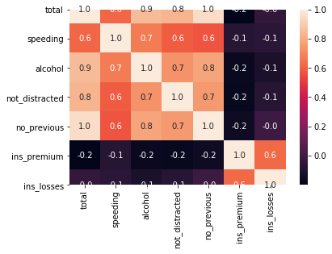

```python
sns.heatmap(x,annot=True,fmt='.1f')
```

```python
y=b.corr()
```

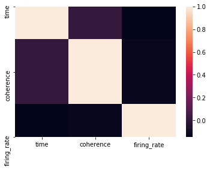

```python
sns.heatmap(y)
```

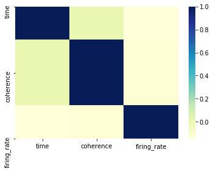

```python
sns.heatmap(y,cmap='YlGnBu')
```

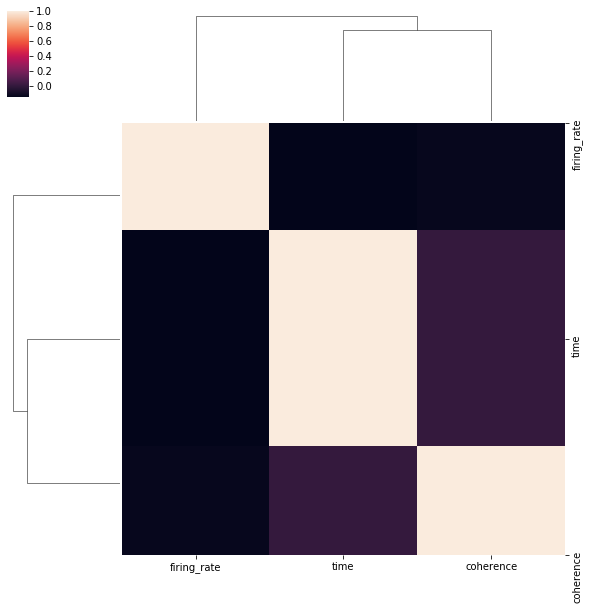

```python
sns.clustermap(y)
```